# Aprendizaje de máquina: proyecto final

Elizabeth Viveros Vergara y Juan B. Martínez Parente

24 de noviembre de 2018

## Introducción

El objetivo de este trabajo es probar distintos modelos de aprendizaje de máquina con el fin de comparar resultados; además, consideraremos dos bases de datos de interés:

- Listado de propiedades en Airbnb para Berlín, París, Roma y Barcelona (descargadas en [Inside Airbnb](http://insideairbnb.com/get-the-data.html)) con variables descriptivas de cada propiedad (como número de cuartos, número de baños, ubicación, tamaño, etc.), además de inforamción de los *hosts*, *ratings*, entre otros. Tomaremos como variable dependiente el precio por noche de cada propiedad (problema de regresión).
- Información recopilada de fuentes del [Coneval](http://coneval.org.mx), [INEGI](http://sc.inegi.org.mx/cobdem/contenido.jsp?rf=false&solicitud=), [Conapo](http://www.conapo.gob.mx/es/CONAPO/Publicaciones) e [INAFED](http://www.inafed.gob.mx/en/inafed/Socioeconomico_Municipal) a nivel municipio provenientes de diferentes encuestas de 2010 y relacionadas con el índice de marginación (rubros de salud, educación, vivienda, seguridad, economía). La variable dependiente será el grado de marginación como lo determina la CONAPO (problema de claseificación).

Utilizaremos R para programar los siguientes modelos:

- regresión lineal con regularización,
- *gradient boosting*
- árboles extremadamente aleatorizados (*extremely randomized trees*).

## Limpieza y exploración de los datos

### Airbnb

Las bases en crudo de cada ciudad contienen las mismas variables. Se unieron todas las bases en una sola “base maestra” y se eliminaron

1. las variables con una proporción muy alta de valores nulos (como `square_feet`);
2. las variables categóricas con muchos niveles (en general, más de 30), como `neighbourhood_cleansed`, `neighborhood_overview`, `street`, `jurisdiction_names`, entre otras;
3. las variables de texto (`name`, `sumary`, `notes`, `host_name`, `host_about`, etc.;

ya que no están realmente relacionadas con el precio por una noche en las distintas propiedades. Algunas de ellas podrían resultar interesantes en otros tipo de anális (por ejemplo, *text mining*).

Cabe notar que las variables fueron filtradas para evitar que tomaran valores atípicos tanto hacia arriba como hacia abajo (en general, se tomaron por arriba del cuantil 0.05 y por debajo del cuantil 0.95).

```r
library(tidyverse)
library(magrittr)
library(data.table)

archivos <- list.files('datos/airbnb/', pattern = 'csv', recursive = F)

listings_raw <- map(archivos, ~fread(paste0('datos/airbnb/', .),
                                     colClasses = c('id' = 'text',
                                                    'zipcode' = 'text'),
                                     encoding = 'UTF-8')) %>%
  bind_rows()

listings_raw %<>%
  select(-c(contains('url'), description, scrape_id, name, summary, space,
            neighborhood_overview, notes,
            transit, access, interaction, house_rules, host_name,
            host_location, host_about,
            host_neighbourhood, neighbourhood, neighbourhood_cleansed, city,
            state,  weekly_price, monthly_price, host_response_rate,
            market:country_code, amenities, host_verifications,
            requires_license,
            host_acceptance_rate, host_listings_count, square_feet,
            jurisdiction_names, last_scraped, host_has_profile_pic,
            street, neighbourhood_group_cleansed, license, calendar_updated,
            host_since, calendar_last_scraped, first_review, last_review,
            experiences_offered, has_availability,
            is_business_travel_ready)) %>%
  filter(property_type %in% c('Hostel', 'Bed and breakfast', 'Loft',
                              'Condominium', 'House', 'Apartment')) %>%
  mutate_at(vars(contains('price'), security_deposit, cleaning_fee,
                 extra_people),
            funs(parse_number)) %>%
  # mutate(zipcode = as.numeric(zipcode)) %>%
  mutate_at(vars(id, review_scores_rating, accommodates, bathrooms, bedrooms,
                 beds, guests_included, reviews_per_month),
            funs(as.numeric)) %>%
  dplyr::filter(!country %in% c('Vatican City', 'Switzerland'))

listing_mod <- listings_raw %>%
  dplyr::filter(property_type %in% c('Hostel', 'Bed and breakfast', 'Loft',
                                     'Condominium', 'House', 'Apartment'),
                accommodates <= 6,
                beds > 0, beds <= 4,
                bedrooms > 0, bedrooms <= 3,
                bathrooms > 0, bathrooms <= 2,
                guests_included <= 4,
                reviews_per_month <= 4,
                price > 25, price <= 200) %>%
  select(id, country, price, review_scores_rating, room_type, property_type,
         accommodates, bathrooms, beds, guests_included, bed_type,
         reviews_per_month, cleaning_fee, security_deposit, zipcode,
         bedrooms, latitude, longitude) %>%
  mutate(cleaning_fee = ifelse(is.na(cleaning_fee)|cleaning_fee == 0, '0', '1'),
         security_deposit = ifelse(is.na(security_deposit)|security_deposit == 0, '0', '1'),
         bed_type = ifelse(bed_type != 'Real Bed', 'Other', bed_type),
         room_type = ifelse(room_type != 'Entire home/apt', 'Private/shared',
                            room_type)) %>%
  na.omit() %>%
  mutate_if(is.character, funs(as.factor)) %>%
  mutate(longitude = round(as.numeric(as.character(longitude)), 2),
         latitude = round(as.numeric(as.character(latitude)), 2)) %>%
  mutate_at(vars(accommodates, bathrooms, beds, zipcode, bedrooms, guests_included, cleaning_fee),
            funs(as.factor)) %>%
  group_by(zipcode) %>%
  filter(n() >= 100, zipcode != '') %>%
  ungroup()
```

```r
listing_mod$price %>% quantile(c(0.3, 0.7, 1))
```

```
##  30%  70% 100%
##   53   90  200
```

```r
listing_mod %<>%
  mutate(price_gr = factor(ifelse(price < 50, 'low',
                           ifelse(price < 90, 'medium', 'high')),
                           levels = c('low', 'medium', 'high'))) %>%
  mutate_if(is.numeric, funs(log))
```

Finalmente, separamos la muestra en entrenamiento y prueba (70% y 30%, respectivamente):

```r
set.seed(124458)
entrena <- sample_frac(listing_mod, 0.7)
prueba <- listing_mod %>% dplyr::filter(!id %in% entrena$id) %>% select(-id)
entrena %<>% select(-id)

save(entrena, prueba, file = 'datos/bases_airbnb.RData')

entrena
```

```
## # A tibble: 40,896 x 18
##    country price review_scores_r~ room_type property_type accommodates
##    <fct>   <dbl>            <dbl> <fct>     <fct>         <fct>
##  1 France   4.32             4.61 Entire h~ Apartment     2
##  2 France   4.23             4.57 Entire h~ Apartment     4
##  3 Italy    3.87             4.55 Private/~ Condominium   3
##  4 France   3.69             4.61 Private/~ Apartment     2
##  5 France   3.91             4.61 Entire h~ Loft          2
##  6 Italy    3.89             4.52 Entire h~ Loft          2
##  7 France   4.79             4.57 Entire h~ Apartment     4
##  8 France   4.13             4.54 Entire h~ Apartment     2
##  9 Italy    3.99             4.51 Private/~ Apartment     2
## 10 France   3.61             4.58 Private/~ Apartment     2
## # ... with 40,886 more rows, and 12 more variables: bathrooms <fct>,
## #   beds <fct>, guests_included <fct>, bed_type <fct>,
## #   reviews_per_month <dbl>, cleaning_fee <fct>, security_deposit <fct>,
## #   zipcode <fct>, bedrooms <fct>, latitude <dbl>, longitude <dbl>,
## #   price_gr <fct>
```

#### Exploratorio

Se hizo un breve análisis exploratorio de las variables seleccionadas. Se observa que el precio alcanza distintos niveles según los valores de las diferentes variables:

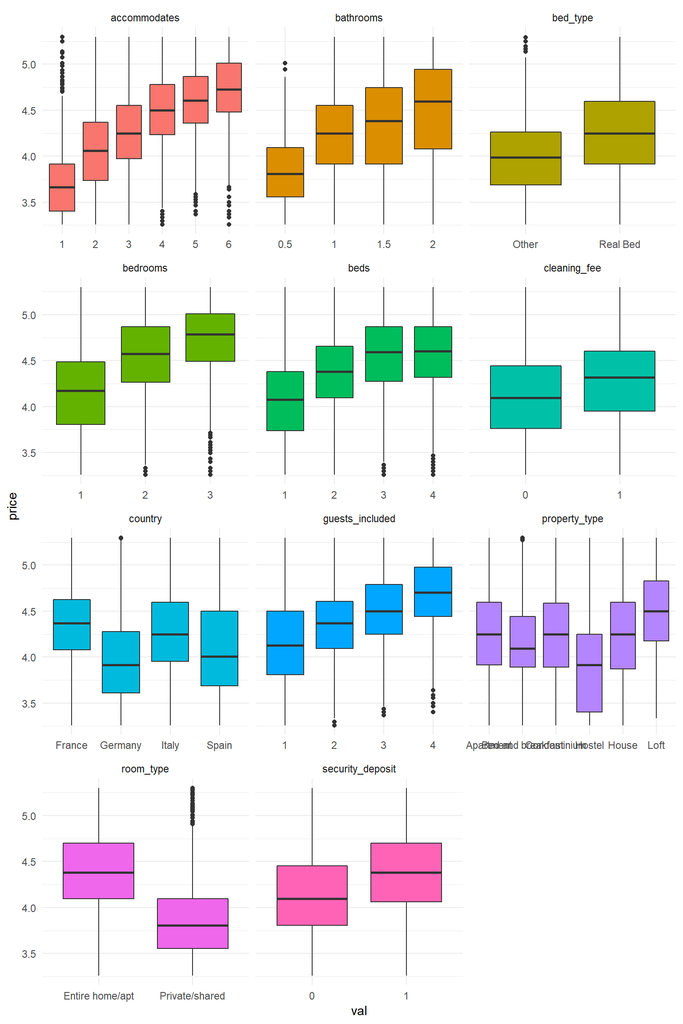

```r
listing_mod %>%
  gather(var, val, c(country, room_type:bed_type, cleaning_fee,
                     security_deposit, bedrooms)) %>%
  ggplot(aes(val, price)) +
  facet_wrap(~var, scales = 'free_x', ncol = 3) +
  geom_boxplot(aes(fill = var)) +
  theme_minimal() +
  theme(legend.position = 'none')
```

### Grado de marginación

Se creo la base de datos del Índice de marginación de 2010 a nivel municipal a partir de las fuentes mencionadas arriba (INEGI, CONAPO, INAFED y Coneval) y se eligieron las variables que a continuación se mencionan para predecir el grado de marginación (muy bajo, bajo, medio, alto y muy alto), es decir, tratándose de un problema de clasificación:

- PIB per cápita
- Proporción de la población que vive en pobreza
- Proporción de la población que vive en pobreza extrema
- Proporción de la población que vive en pobreza moderada
- Proporción de la población con ingreso inferior a la línea de bienestar
- Proporción de la población con ingreso inferior a la línea de bienestar mínimo
- Proporción de la población con rezago educativo
- Proporción de la población sin acceso a los servicios básicos en la vivienda
- Proporción de la población con carencia por acceso a la alimentación
- Proporción de la población sin acceso a la seguridad social
- Proporción de la población sin acceso a los servicios de salud
- Proporción de la población con carencia por calidad y espacios de la vivienda
- Proporción de la población de 15 años o más analfabeta
- Proporción de la población en viviendas sin drenaje ni excusado
- Proporción de la población en viviendas sin energía eléctrica
- Proporción de la población en viviendas sin agua entubada
- Proporción de la población en viviendas con piso de tierra
- Tasa de mortalidad infantil
- Proporción de la población sin derechohabiencia
- Proporción de la población desocupada de 12 años y más

```r
IM <- fread('datos/bae_IM.csv', encoding = 'UTF-8') %>%
  select(-predicted) %>%
  mutate(id = 1:nrow(.))

IM %>% names
```

```
##  [1] "Grado de marginación"
##  [2] "Índice de marginación"
##  [3] "PIB per cápita"
##  [4] "Pobreza (proporción)"
##  [5] "Pobreza extrema (proporción)"
##  [6] "Pobreza moderada (proporción)"
##  [7] "Población con ingreso inferior a la línea de bienestar (proporción)"
##  [8] "Población con ingreso inferior a la línea de bienestar mínimo (proporción)"
##  [9] "Rezago educativo (proporción)"
## [10] "Carencia por acceso a los servicios básicos en la vivienda (proporción)"
## [11] "Carencia por acceso a la alimentación (proporción)"
## [12] "Carencia por acceso a la seguridad social (proporción)"
## [13] "Carencia por acceso a los servicios de salud (proporción)"
## [14] "Carencia por calidad y espacios de la vivienda (proporción)"
## [15] "Mortalidad infantil (proporción)"
## [16] "Población sin derechohabiencia (proporción)"
## [17] "Población desocupada de 12 años y más (proporción)"
## [18] "id"
```

```r
names(IM) <- c(
  'grado_IM',
  'indices_IM',
  'PIB_per_capita',
  'pobreza',
  'pobreza_extrema',
  'pobreza_moderada',
  'inf_bienestar',
  'inf_bienestar_min',
  'rezago_edu',
  'car_servicios_vivienda',
  'car_alimentacion',
  'car_seguridad',
  'car_salud',
  'car_espacios_vivienda',
  'mort_infantil',
  'sin_acceso_salud',
  'pob_desocupada',
  'id'
)

IM <- IM %>%
  mutate(grado_IM = ifelse(grado_IM == 0, '1 Muy bajo',
                           ifelse(grado_IM == 1, '2 Bajo',
                                  ifelse(grado_IM == 2, '3 Medio',
                                         ifelse(grado_IM == 3, '4 Alto', '5 Muy alto'))))) %>%
  mutate(grado_IM = factor(grado_IM))


set.seed(10585)
entrena <- sample_frac(IM, 0.7)
prueba <- IM %>% dplyr::filter(!id %in% entrena$id) %>% select(-id)
entrena %<>% select(-id)

x <- model.matrix(~., entrena[,-c(1, 2)])
y <- as.factor(entrena$grado_IM)

x.test <- model.matrix(~., prueba[,-c(1,2)])
y.test <- as.factor(prueba$grado_IM)

save(entrena, prueba, x, y, x.test, y.test, file = 'datos/bases_indice.RData')
```

#### Exploratorio

El análisis exploratorio está en el anexo ‘EDA_mariginacion.Md’.

## Modelos

Como se mecionó anteriormente, el objetivo del actual proyecto es comparar el desempeño de tres distintos tipos de modelos (regresión con regularización, *gradient boosting* y extremely randomized trees_. A continuación presentamos los resultados para cada base de datos.

En todos los casos se hizo validación cruzada con la librería `caret` para elegir los parámetros que minimizan el error cuadrático medio (en el caso de regresión) y los que maximizan la precisión (en el caso de clasificación). Los parámetros de la validación cruzada fueron:

```r
library(caret)

fitControl <- trainControl(
  method = "repeatedcv",
  number = 10,
  repeats = 10)
```

### Airbnb

#### Regresión lineal con regularización Ridge y Lasso

Primero se hizo la validación cruzada para $\alpha \in \{ 0, 0.05, 0.1, \dots, 0.95, 1 \}$ y para $\lambda \in \{ e^{-5}, e^{-4}, \dots, e^4, e^5\}$.

```r
library(glmnet)
x <- model.matrix(~., entrena[,-c(2,18)])
y <- entrena$price

# test_class_cv_model <- train(x, y,
#                             method = "glmnet",
#                             trControl = fitControl
#                             metric = "RMSE",
#                             tuneGrid = expand.grid(.alpha = seq(0, 1, 0.05),
#                                                    .lambda = exp(seq(-5,5,1))))

load('crossval/cv_reg_airbnb.RData')

test_class_cv_model$bestTune
```

```
##    alpha      lambda
## 12  0.05 0.006737947
```

Los valores que resultaron ótpimos para el error cuadrático medio fueron $\alpha = 0.05$ y $\lambda = e^{-5}$. Corremos entonces el modelo y calculamos, para el conjunto de prueba, el error cuadrático medio y la asociación lineal (la correlación entre los valores observados y los valores predichos):

```r
load('datos/bases_airbnb.RData')

x <- model.matrix(~., entrena[,-c(2,18)])
y <- entrena$price

mod_ridge <- glmnet(x, y,
                    alpha = 0.05,
                    family = 'gaussian',
                    intercept = T,
                    lambda = 0.006737947)

x.test <- model.matrix(~., prueba[,-c(2, 18)])
y.test <- prueba$price

df.reg <- data.frame(pred = predict(mod_ridge, x.test),
                     obs = prueba$price,
                     pred.exp = exp(predict(mod_ridge, x.test)),
                     obs.exp = exp(prueba$price),
                     country = prueba$country) %>%
  mutate(residuo = obs - s0)

rmse_reg <- sqrt(sum((df.reg$obs.exp - df.reg$s0.1)^2) / nrow(df.reg))
rmse_reg
```

```
## [1] 27.40256
```

```r
as_lin_reg <- cor(df.reg$obs, df.reg$s0)^2
as_lin_reg
```

```
## [1] 0.5351157
```

```r
library(broom)
tidy(mod_ridge) %>% select(term, estimate)
```

```
## # A tibble: 134 x 2
##    term                           estimate
##    <chr>                             <dbl>
##  1 (Intercept)                      2.75
##  2 countryGermany                  -0.0928
##  3 countrySpain                    -0.0813
##  4 review_scores_rating             0.170
##  5 room_typePrivate/shared         -0.313
##  6 property_typeBed and breakfast   0.299
##  7 property_typeCondominium         0.0202
##  8 property_typeHostel              0.129
##  9 property_typeHouse               0.0752
## 10 property_typeLoft                0.155
## # ... with 124 more rows
```

### *Gradient boosting*

Hicimos validación cruzada para los parámetros `interaction.depth` en el conjunto $\{1,2,3\}$, `n.trees` en el conjunto $\{50,100,150\}$. `shrinkage` y `n.minobsinnode` se tomaron constantes con los valores respectivos de $0.1$ y $10$.

```r
library(gbm)
#gbmFit1 <- train(price ~ ., data = entrena,
#                 method = "gbm",
#                 trControl = fitControl,
#                 verbose = FALSE)

load('crossval/cv_gbm_airbnb.RData')

gbmFit1$bestTune
```

```
##   n.trees interaction.depth shrinkage n.minobsinnode
## 9     150                 3       0.1             10
```

Los valores que resultaron ótpimos para el error cuadrático medio fueron `interaction.depth = 3` y `n.trees = 150`. Corremos entonces el modelo y calculamos, para el conjunto de prueba, el error cuadrático medio y la asociación lineal (la correlación entre los valores observados y los valores predichos):

```r
mod_boosting <- gbm(price ~ .,
                    data = entrena %>% select(-c(price_gr)),
                    n.trees = 500,
                    interaction.depth = 3,
                    shrinkage = 0.1, # tasa de aprendizaje
                    n.minobsinnode = 10,
                    bag.fraction = 1,
                    train.fraction = 0.75)
```

```
## Distribution not specified, assuming gaussian ...
```

```r
df.gbm <- data.frame(pred = predict(mod_boosting, prueba),
                     obs = prueba$price,
                     country = prueba$country) %>%
  mutate(pred.exp = exp(pred),
         obs.exp = exp(obs)) %>%
  mutate(residuo = obs - pred)
```

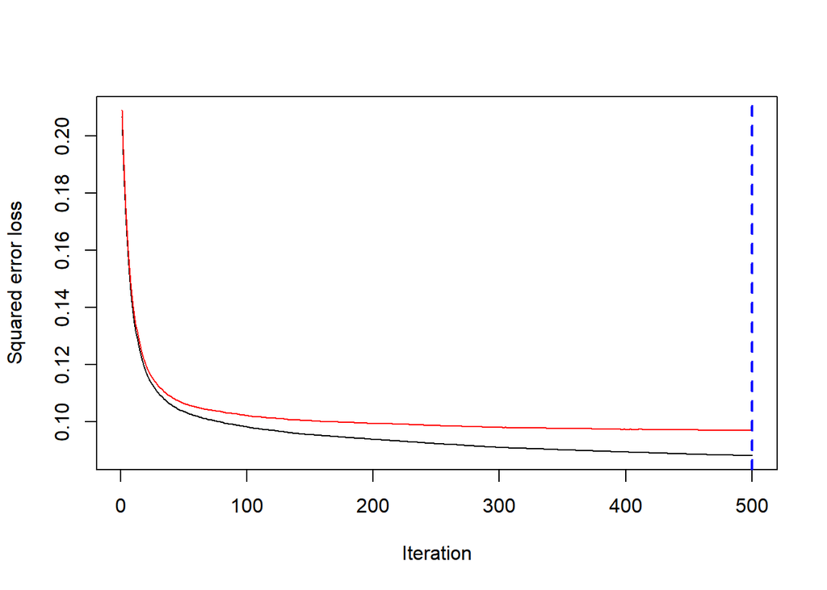

```
## Using 500 trees...
```

```r
rmse_gbm <- sqrt(sum((df.gbm$obs.exp - df.gbm$pred.exp)^2) / nrow(df.gbm))
rmse_gbm
```

```
## [1] 26.19675
```

```r
as_lin_gbm <- cor(df.gbm$obs, df.gbm$pred)^2
as_lin_gbm
```

```
## [1] 0.5752033
```

### *Extremely randomized trees*

```r
library(extraTrees)
# gbmFit2 <- train(x, y,
#                 method = "extraTrees",
#                 trControl = fitControl)


load('crossval/cv_ET_airbnb.RData')

gbmFit2$bestTune
```

```
##   mtry numRandomCuts
## 1    5            18
```

```r
# load('datos/mod_ET.RData')

mod_ET <- extraTrees(x, y, mtry = 5, numRandomCuts = 18)

df.ET <- data.frame(pred = predict(mod_ET, x.test),
                 obs = prueba$price,
                 country = prueba$country) %>%
  mutate(pred.exp = exp(pred),
         obs.exp = exp(obs)) %>%
  mutate(residuo = obs - pred)

rmse_ET <- sqrt(sum((df.ET$obs.exp - df.ET$pred.exp)^2) / nrow(df.ET))
rmse_ET
```

```
## [1] 26.76521
```

```r
as_lin_ET <- cor(df.ET$obs, df.ET$pred)^2
as_lin_ET
```

```
## [1] 0.5505546
```

### Comparación de los resultados

```r
rmse_df <- data.frame(modelo = c('regularizacion', 'gbm', 'extra_trees'),
                      rmse = c(rmse_reg, rmse_gbm, rmse_ET),
                      asociacion_lineal = c(as_lin_reg, as_lin_gbm, as_lin_ET))
rmse_df
```

```
##           modelo     rmse asociacion_lineal
## 1 regularizacion 27.40256         0.5351157
## 2            gbm 26.19675         0.5752033
## 3    extra_trees 26.76521         0.5505546
```

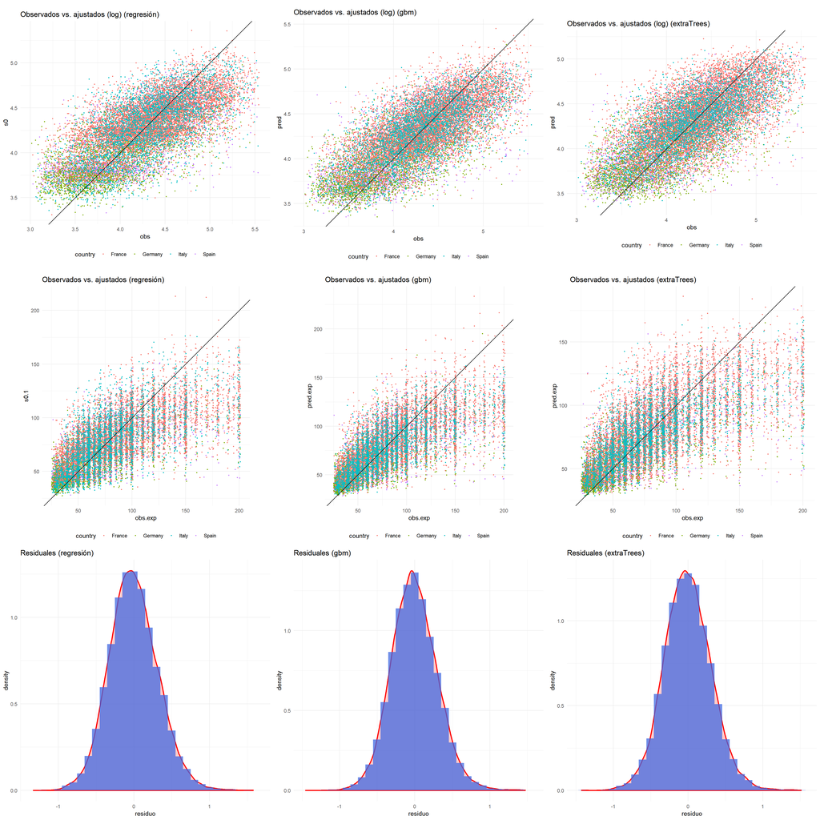

```r
library(Rmisc)

ajuste_reg <- df.reg %>%
  ggplot(aes(obs, s0)) +
  geom_jitter(aes(color = country), size = 0.5, width = 0.25) +
  geom_abline() +
  coord_equal() +
  theme_minimal() +
  theme(legend.position = 'bottom') +
  labs(title = 'Observados vs. ajustados (log) (regresión)')

ajuste_reg_exp <- df.reg %>%
  ggplot(aes(obs.exp, s0.1)) +
  geom_jitter(aes(color = country), size = 0.5, width = 1) +
  geom_abline() +
  coord_equal() +
  scale_x_continuous(labels = scales::comma) +
  scale_y_continuous(labels = scales::comma) +
  theme_minimal() +
  theme(legend.position = 'bottom') +
  labs(title = 'Observados vs. ajustados (regresión)')

residuales_reg <- df.reg %>%
  ggplot(aes(residuo)) +
  geom_density(color = 'red', size = 1, fill = 'red', alpha = 0.2) +
  geom_histogram(aes(y = ..density..), fill = 'royal blue', alpha = 0.75) +
  theme_minimal() +
  theme(legend.position = 'bottom') +
  labs(title = 'Residuales (regresión)')

ajuste_gbm <- df.gbm %>%
  ggplot(aes(obs, pred)) +
  geom_jitter(aes(color = country), size = 0.5, width = 0.25) +
  geom_abline() +
  coord_equal() +
  theme_minimal() +
  theme(legend.position = 'bottom') +
  labs(title = 'Observados vs. ajustados (log) (gbm)')

ajuste_gbm_exp <- df.gbm %>%
  ggplot(aes(obs.exp, pred.exp)) +
  geom_jitter(aes(color = country), size = 0.5, width = 1) +
  geom_abline() +
  coord_equal() +
  scale_x_continuous(labels = scales::comma) +
  scale_y_continuous(labels = scales::comma) +
  theme_minimal() +
  theme(legend.position = 'bottom') +
  labs(title = 'Observados vs. ajustados (gbm)')

residuales_gbm <- df.gbm %>%
  ggplot(aes(residuo)) +
  geom_density(color = 'red', size = 1, fill = 'red', alpha = 0.2) +
  geom_histogram(aes(y = ..density..), fill = 'royal blue', alpha = 0.75) +
  theme_minimal() +
  theme(legend.position = 'bottom') +
  labs(title = 'Residuales (gbm)')

ajuste_ET <- df.ET %>%
  ggplot(aes(obs, pred)) +
  geom_jitter(aes(color = country), size = 0.5, width = 0.25) +
  geom_abline() +
  coord_equal() +
  theme_minimal() +
  theme(legend.position = 'bottom') +
  labs(title = 'Observados vs. ajustados (log) (extraTrees)')

ajuste_ET_exp <- df.ET %>%
  ggplot(aes(obs.exp, pred.exp)) +
  geom_jitter(aes(color = country), size = 0.5, width = 1) +
  geom_abline() +
  coord_equal() +
  scale_x_continuous(labels = scales::comma) +
  scale_y_continuous(labels = scales::comma) +
  theme_minimal() +
  theme(legend.position = 'bottom') +
  labs(title = 'Observados vs. ajustados (extraTrees)')

residuales_ET <- df.ET %>%
  ggplot(aes(residuo)) +
  geom_density(color = 'red', size = 1, fill = 'red', alpha = 0.2) +
  geom_histogram(aes(y = ..density..), fill = 'royal blue', alpha = 0.75) +
  theme_minimal() +
  theme(legend.position = 'bottom') +
  labs(title = 'Residuales (extraTrees)')

multiplot(ajuste_reg, ajuste_reg_exp, residuales_reg,
          ajuste_gbm, ajuste_gbm_exp, residuales_gbm,
          ajuste_ET, ajuste_ET_exp, residuales_ET,
          cols = 3)
```

En general, los tres modelos se comportan de forma muy similar. El error cuadrático medio es muy cercano en cada caso (alrededor de 26 euros), y el ajuste lineal es bastante malo (entre 0.53 y 0.57). Sin emabrgo, si hubiera que elegir un modelo, la mejor elección sería el de *gradient boosting*.

La calidad del ajuste no se debe a algún problema en los modelos seleccionados, sino a los datos. No tiene sentido incorporar las variables que en un inicio se quitaron de la base, ya que, como se vio, no guardan relación con el precio. Valdría la pena, en un segundo ejercicio, buscar fuentes de información ajenas a Airbnb que complementen los datos y ayuden a mejorar el ajuste (quizá exista información sobre la edad promedio de los edificios por zona en las ciudades que tomamos o alguna variable similar).

### Grado de marginación

#### Regresión lineal con regularización Ridge y Lasso

La validación cruzada arrojó los siguientes valores óptimos para el error cuadrático medio: $\alpha = 0.05$ y $\lambda = e^{-5}$.

```r
library(glmnet)
x <- model.matrix(~., entrena[,-c(2,18)])
y <- entrena$price

# test_class_cv_model <- train(x, y,
#                             method = "glmnet",
#                             trControl = cctrlR,
#                             tuneGrid = expand.grid(.alpha = seq(0, 1, 0.05),
#                                                    .lambda = exp(seq(-5,5,1))))

load('crossval/cv_reg_indice.RData')

test_class_cv_model$bestTune
```

```
##    alpha      lambda
## 12  0.05 0.006737947
```

Corremos entonces el modelo y calculamos, para el conjunto de prueba, el error cuadrático medio y la asociación lineal (la correlación entre los valores observados y los valores predichos):

```r
load('datos/bases_indice.RData')

mod_ridge <- glmnet(x, y,
                    family = 'multinomial',
                    alpha = 0.05,
                    intercept = T,
                    lambda = 0.006737947)

df.reg <- data.frame(pred = predict(mod_ridge, x.test, type = 'response')) %>%
  mutate(num = apply(., 1, which.max),
         # num = as.numeric(num),
         obs = y.test) %>%
  mutate(pred = ifelse(num == 1, '1 Muy bajo',
                       ifelse(num == 2, '2 Bajo',
                              ifelse(num == 3, '3 Medio',
                                     ifelse(num == 4, '4 Alto', '5 Muy alto')))))

acc_reg <- round(100 * sum(df.reg$obs == df.reg$pred) / nrow(df.reg), 1)
acc_reg
```

```
## [1] 72.7
```

```r
conf_matrix_reg <- round(100 * prop.table(table(df.reg$obs, df.reg$pred), margin = 1), 1)
diag_reg <- diag(conf_matrix_reg)

conf_matrix_reg
```

```
##
##              1 Muy bajo 2 Bajo 3 Medio 4 Alto 5 Muy alto
##   1 Muy bajo       73.8   23.8     2.5    0.0        0.0
##   2 Bajo           11.1   54.0    34.9    0.0        0.0
##   3 Medio           0.7    5.8    85.9    6.5        1.0
##   4 Alto            0.0    0.0    31.4   50.8       17.8
##   5 Muy alto        0.0    0.0     1.6   17.2       81.1
```

```r
conf_matrix_reg %<>%
  as.data.frame() %>%
  setNames(c('obs', 'pred', 'freq_reg'))

tidy(mod_ridge) %>% select(class, term, estimate) %>% spread(class, estimate)
```

```
## # A tibble: 16 x 6
##    term              `1 Muy bajo` `2 Bajo` `3 Medio` `4 Alto` `5 Muy alto`
##    <chr>                    <dbl>    <dbl>     <dbl>    <dbl>        <dbl>
##  1 ""                       8.08     2.77   -1.40      -4.08       -5.36
##  2 car_alimentacion         3.70    -0.408  -1.19      -1.69        0.0806
##  3 car_espacios_viv~       -4.16    -2.55   -0.230      2.24        5.02
##  4 car_salud                5.31     2.07   -0.678     -2.10       -4.30
##  5 car_seguridad           -1.33     0.813   0.834     -1.22        0.623
##  6 car_servicios_vi~       -3.74    -1.53    1.09       1.95        2.05
##  7 inf_bienestar            0.119   -0.229  -0.529      1.03       -0.0914
##  8 inf_bienestar_min       -4.86    -4.05   -1.29       4.42        6.06
##  9 mort_infantil           -6.53    -1.49   -0.627      2.07        7.34
## 10 PIB_per_capita          -8.68     2.79    4.66       3.47       -3.17
## 11 pob_desocupada          24.5     16.5    NA        -15.4       -22.4
## 12 pobreza                 -3.52    -1.48    2.38       2.11        0.230
## 13 pobreza_extrema         -3.70    -5.01    0.167      3.27        4.99
## 14 pobreza_moderada        -0.326    7.22    5.60      -1.50      -10.6
## 15 rezago_edu             -11.1     -8.38    0.00128    6.66       12.3
## 16 sin_acceso_salud        -3.09    -0.149   0.734      0.778       1.43
```

### *Gradient boosting*

Se usaron los mismos valores para la validación cruzada que para la base de Airbnb. De igual forma, los valores que resultaron ótpimos para el error cuadrático medio fueron `interaction.depth = 3` y `n.trees = 150`.

```r
# gbmFit1 <- train(as.factor(grado_IM) ~ ., data = entrena %>% select(-indices_IM),
#                 method = "gbm",
#                 trControl = fitControl,
#                 verbose = FALSE)

load('crossval/cv_gbm_indice.RData')

gbmFit1$bestTune
```

```
##   n.trees interaction.depth shrinkage n.minobsinnode
## 9     150                 3       0.1             10
```

Corremos entonces el modelo y calculamos, para el conjunto de prueba, el error cuadrático medio y la asociación lineal (la correlación entre los valores observados y los valores predichos):

```r
mod_boosting <- gbm(factor(grado_IM) ~ .,
                    data = entrena %>% select(-indices_IM),
                    n.trees = 150,
                    interaction.depth = 3,
                    shrinkage = 0.1,
                    n.minobsinnode = 10,
                    bag.fraction = 1,
                    train.fraction = 0.75)
```

```
## Distribution not specified, assuming multinomial ...
```

```r
df.gbm <- data.frame(pred = predict(mod_boosting, prueba %>% mutate(grado_IM = factor(grado_IM)),
                                    type = 'response')) %>%
  mutate(num = apply(., 1, which.max),
         obs = as.character(prueba$grado_IM)) %>%
  mutate(pred = ifelse(num == 1, '1 Muy bajo',
                       ifelse(num == 2, '2 Bajo',
                              ifelse(num == 3, '3 Medio',
                                     ifelse(num == 4, '4 Alto', '5 Muy alto')))))
```

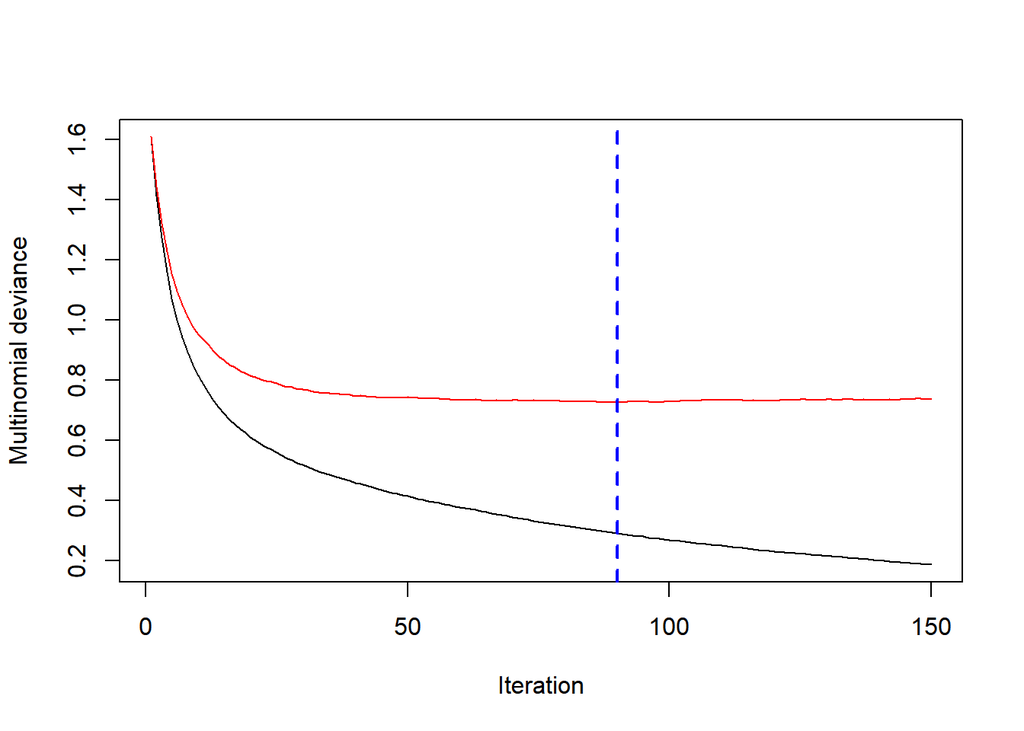

```
## Using 90 trees...
```

```r
acc_gbm <- round(100 * sum(df.gbm$obs == df.gbm$pred) / nrow(df.gbm), 1)
acc_gbm
```

```
## [1] 75.3
```

```r
conf_matrix_gbm <- round(100 * prop.table(table(df.gbm$obs, df.gbm$pred), margin = 1), 1)

diag_gbm <- diag(conf_matrix_gbm)
conf_matrix_gbm
```

```
##
##              1 Muy bajo 2 Bajo 3 Medio 4 Alto 5 Muy alto
##   1 Muy bajo       71.2   27.5     1.2    0.0        0.0
##   2 Bajo            7.1   59.5    33.3    0.0        0.0
##   3 Medio           0.0    4.1    85.6    8.9        1.4
##   4 Alto            0.0    0.0    18.6   59.3       22.0
##   5 Muy alto        0.0    0.0     0.8   13.9       85.2
```

```r
conf_matrix_gbm %<>%
  as.data.frame() %>%
  setNames(c('obs', 'pred', 'freq_gbm'))
```

### *Extremely randomized trees*

```r
# gbmFit1 <- train(x, y,
#                 method = "extraTrees",
#                 trControl = fitControl)

load('crossval/cv_ET_indice.RData')

gbmFit1$bestTune
```

```
##   mtry numRandomCuts
## 3    2             3
```

Los valores que resultaron ótpimos para el error cuadrático medio fueron `mtry = 2` y `numRandomCuts = 3`. Corremos entonces el modelo y calculamos, para el conjunto de prueba, el error cuadrático medio y la asociación lineal (la correlación entre los valores observados y los valores predichos):

```r
mod_ET <- extraTrees(x, y, ntree = 1000, mtry = 2, numRandomCuts = 3)

df.ET <- data.frame(pred = predict(mod_ET, x.test),
                    obs = prueba$grado_IM)

acc_ET <- round(100 * sum(df.ET$obs == df.ET$pred) / nrow(df.ET), 1)
acc_ET
```

```
## [1] 75.3
```

```r
conf_matrix_ET <- round(100 * prop.table(table(df.ET$obs, df.ET$pred), margin = 1), 1)

diag_ET <- diag(conf_matrix_ET)
conf_matrix_ET
```

```
##
##              1 Muy bajo 2 Bajo 3 Medio 4 Alto 5 Muy alto
##   1 Muy bajo       76.2   22.5     1.2    0.0        0.0
##   2 Bajo            7.1   61.9    31.0    0.0        0.0
##   3 Medio           0.0    3.8    85.9    9.3        1.0
##   4 Alto            0.0    0.0    25.4   53.4       21.2
##   5 Muy alto        0.0    0.0     0.8   14.8       84.4
```

```r
conf_matrix_ET %<>%
  as.data.frame() %>%
  setNames(c('obs', 'pred', 'freq_ET'))
```

### Comparación de los resultados

```r
conf_reg <- conf_matrix_reg %>%
  ggplot(aes(pred, obs)) +
  geom_tile(aes(fill = freq_reg)) +
  geom_text(aes(pred, obs, label = freq_reg)) +
  scale_fill_continuous(low = 'white', high = 'dark green',
                        limits = c(0,100)) +
  theme_minimal() +
  theme(legend.position = 'none') +
  labs(title = 'Matriz de confusión (regresión)')

conf_gbm <- conf_matrix_gbm %>%
  ggplot(aes(pred, obs)) +
  geom_tile(aes(fill = freq_gbm)) +
  geom_text(aes(pred, obs, label = freq_gbm)) +
  scale_fill_continuous(low = 'white', high = 'dark green',
                        limits = c(0,100)) +
  theme_minimal() +
  theme(legend.position = 'none') +
  labs(title = 'Matriz de confusión (gbm)')

conf_ET <- conf_matrix_ET %>%
  ggplot(aes(pred, obs)) +
  geom_tile(aes(fill = freq_ET)) +
  geom_text(aes(pred, obs, label = freq_ET)) +
  scale_fill_continuous(low = 'white', high = 'dark green',
                        limits = c(0,100)) +
  theme_minimal() +
  theme(legend.position = 'none') +
  labs(title = 'Matriz de confusión (extraTrees)')

acc_df <- data.frame(modelo = c('regularizacion', 'gbm', 'extra_trees'),
             accuracy = c(acc_reg, acc_gbm, acc_ET))

acc_df
```

```
##           modelo accuracy
## 1 regularizacion     72.7
## 2            gbm     75.3
## 3    extra_trees     75.3
```

```r
conf_matrices <- data.frame(reg = diag_reg,
                            gbm = diag_gbm,
                            ET = diag_ET)

conf_matrices
```

```
##             reg  gbm   ET
## 1 Muy bajo 73.8 71.2 76.2
## 2 Bajo     54.0 59.5 61.9
## 3 Medio    85.9 85.6 85.9
## 4 Alto     50.8 59.3 53.4
## 5 Muy alto 81.1 85.2 84.4
```

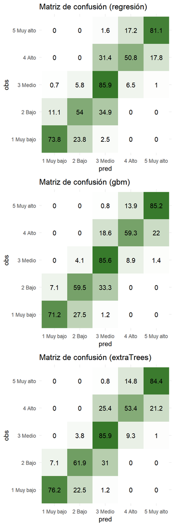

```r
multiplot(conf_reg, conf_gbm, conf_ET)
```

Si se observa los valores de las diagonales de las matrices confusión, vemos que *extremely randomized trees* no es el mejor prediciendo en todos los niveles del índice de marginación. La regresión con regularización es la que mjor predice el nivel de marginación medio, *gradient boosting* predice mejor los niveles alto y muy alto, y *extremely randomized trees* es el mejor prediciendo los niveles muy bajo y bajo.